# Hito 1 - Minería de Datos CC5205

Grupo 19: Catalina Carrasco, Javiera Donoso, Joaquín Herrera, Macarena Ríos, Nahuel Sanhueza

# Informe

## Librerias a importar

```r
library(ggplot2)
library(tidyr)
library(GGally)
library(gtools)
library(reshape2)
library(dplyr)
library(corrplot)
library(kableExtra)
library(vtable)

thyroid.df <- read.csv("https://raw.githubusercontent.com/init-nahuel/project-data-mining/main/data/thyroidDF.csv")
```

## Contexto y motivación

El contexto gira en torno a la enfermedad de la tiroides, una glándula ubicada en la base del cuello que desempeña un papel crítico en la producción de hormonas esenciales para el funcionamiento del cuerpo. Esta glándula es de vital importancia, ya que influye en la generación de energía, la regulación del metabolismo y la temperatura corporal, entre otras funciones fundamentales. En la actualidad, según la Organización Mundial de la Salud (OMS) se estima que aproximadamente unas 750 millones de personas padecen de alguna patología tiroidea, de las cuales un 60% lo desconoce.

Este tema toma relevancia en la actualidad dada las innovaciones que existen hoy en día para el tratamiento tanto de hipotiroidismo como de hipertiroidismo. Además, cabe destacar al tener un diagnóstico a temprana edad, disminuye las probabilidades de tener cáncer de tiroides, el cáncer de tiroides fue el diagnóstico de cáncer que aumentó más rápidamente en los Estados Unidos. Los investigadores creen que parte del motivo de este aumento fue que las pruebas de diagnóstico nuevas y altamente sensibles llevaron a una mayor detección de cánceres más pequeños.

La importancia de este tema se basa principalmente en la prevalencia, ya que esta enfermedad es común en todo el mundo, y afecta a un gran número de personas. Comprender mejor esta afección es esencial para la salud pública y la atención médica. Además, es de suma importancia comprender los factores de riesgo, como la edad, el género y los antecedentes familiares, puede ayudar a identificar grupos de población con mayor probabilidad de desarrollar enfermedades tiroideas y permitir una intervención preventiva más efectiva.

A continuación se estudiará un dataset estructurado sobre esta afección denominado “Thyroid Disease Data”. En él se pueden encontrar diversos datos asociados a los pacientes, junto a sus respectivos resultados de análisis de sangre y diagnóstico efectuado por un profesional.

## Exploración de datos

### Dimensiones del dataset

```r
dim(thyroid.df)
```

```
[1] 9172   31
```

Es decir, se tienen 9172 records y 31 atributos.

### Características de los atributos

Los distintos atributos que contiene el dataset se presentan a continuación:

1. age : edad del paciente (int)
2. sex : el sexo del paciente (str)
3. on_thyroxine : si el paciente está tomando tiroxina (bool)
4. query_on_thyroxine : si el paciente está tomando tiroxina (bool)
5. on_antithyroid_meds : si el paciente está tomando medicamentos antitiroideos (bool)
6. sick : si el paciente está enfermo (bool)
7. pregnant : si la paciente está embarazada (bool)
8. thyroid_surgery : si el paciente se ha sometido a una cirugía de tiroides (bool)
9. I131_treatment : si el paciente está recibiendo tratamiento I131 (para el manejo de trastornos tiroideos) (bool)
10. query_hypotoideo : si el paciente cree que tiene hipotiroidismo (bool)
11. query_hyperthyroid : si el paciente cree que tiene hipertiroidismo (bool)
12. lithium : si el paciente * litio (bool)
13. goitre : si el paciente tiene bocio (bool)
14. tumor : si el paciente tiene tumor (bool)
15. hypopituitary : si el paciente * glándula hipopituitaria (bool)
16. psych : si paciente * psych (bool)
17. TSH_measured : si la TSH se midió en la sangre (bool)
18. TSH : nivel de TSH en sangre según análisis de laboratorio (float)
19. T3_measured : si se midió T3 en la sangre (bool)
20. T3 : nivel de T3 en sangre según análisis de laboratorio (float)
21. TT4_measured : si se midió TT4 en la sangre (bool)
22. TT4 : nivel de TT4 en sangre procedente de análisis de laboratorio (float)
23. T4U_measured : si se midió T4U en la sangre (bool)
24. T4U : nivel de T4U en sangre según análisis de laboratorio (float)
25. FTI_measured : si el FTI se midió en la sangre (bool)
26. FTI : nivel de FTI en sangre según análisis de laboratorio (float)
27. TBG_measured : si se midió TBG en la sangre (bool)
28. TBG : nivel de TBG en sangre según análisis de laboratorio (float)
29. referral_source : (str)
30. target : diagnóstico médico de hipertiroidismo (str)
31. patient_id : identificación única del paciente (str)

Como se puede apreciar, la mayoría de los atributos son categóricos (de tipo bool). Por otro lado, los datos de tipo float asociados a los niveles en el análisis de sangre se podrían comparar (previa normalización) para extraer resultados.

De manera más específica, para el atributo “target” existen diversas letras que indican los distintos diagnósticos (aquellos que son de la forma “X|Y” se interpretan como “consistente con X, pero más probable Y”):

1. “-” no hay comentarios sobre un diagnóstico específico

Condiciones de hipertiroidismo:

2. “A” hipertiroidismo
3. “B” T3 tóxico
4. “C” bocio tóxico
5. “D” tóxico secundario

Condiciones de hipotiroidismo:

6. “E” hipotiroidismo
7. “F” hipotiroidismo primario
8. “G” Hipotiroidismo compensado
9. “H” hipotiroidismo secundario

Proteína de unión:

10. “I” proteína de unión aumentada
11. “J” proteína de unión disminuida

Salud general:

12. “K” enfermedad no tiroidea concurrente

Terapia de reemplazo:

13. “L” compatible con terapia de reemplazo
14. “M” insuficientemente reemplazado
15. “N” sobrereemplazado

Tratamiento antitiroideo:

16. “O” medicamentos antitiroideos
17. “P” tratamiento I131
18. “Q” cirugía

Misceláneas:

19. “R” resultados de ensayo discordantes
20. “S” TBG elevada
21. “T” hormonas tiroideas elevadas

Por último, para tener un mejor entendimiento de la situación es importante mencionar las principales características de las hormonas a estudiar. La triyodotironina (T3) y la tiroxina (TT4) son hormonas extremadamente importantes en el sistema endocrino, y cumplen varias funciones clave en el organismo, tales como la regulación del metabolismo, la regulación de la temperatura corporal, el desarrollo y crecimiento, entre otros. Por otro lado, la hormona estimulante de la tiroides (TSH) tiene como función principal la de estimular la glándula tiroides para que produzca y libere las hormonas tiroideas (T3 y TT4) en la sangre. Los valores asociados a T4U, FTI y TBG son índices que muestran los niveles de: captación de tiroxina, tiroxina libre (en la sangre) y globulina transportadora de tiroxina (proteína que se encuentra en el torrente sanguíneo y tiene la función específica de unir y transportar las hormonas tiroideas), respectivamente.

A continuación se presente un resumen con las medidas de tendencia central en conjunto con la proporcion de valores `NA` para los atributos numéricos del dataset:

```r
sumtable(thyroid.df[,c("age", "TSH", "T3", "TT4", "T4U", "FTI")], summ = c('median(x)', 'mean(x)',   'sd(x)', 'min(x)', 'pctile(x)[25]', 'pctile(x)[75]', 'max(x)', 'notNA(x)', 'propNA(x)'), title = "Medidas de Tendencia Central para datos numericos")
```

[output not shown]

### Valores duplicados

```r
sum(duplicated(thyroid.df))
```

```
[1] 0
```

Se observa que no existen valores duplicados en el conjunto de datos.

### Valores faltantes

Total de valores nulos en el dataset:

```r
sprintf("Cantidad de valores nulos: %d", sum(is.na(thyroid.df)))
```

```
[1] "Cantidad de valores nulos: 14322"
```

Valores nulos por atributo:

```r
sapply(thyroid.df, function(x) sum(is.na(x)))
```

```
                age                 sex        on_thyroxine  query_on_thyroxine on_antithyroid_meds                sick            pregnant
                  0                   0                   0                   0                   0                   0                   0
    thyroid_surgery      I131_treatment   query_hypothyroid  query_hyperthyroid             lithium              goitre               tumor
                  0                   0                   0                   0                   0                   0                   0
      hypopituitary               psych        TSH_measured                 TSH         T3_measured                  T3        TT4_measured
                  0                   0                   0                 842                   0                2604                   0
                TT4        T4U_measured                 T4U        FTI_measured                 FTI        TBG_measured                 TBG
                442                   0                 809                   0                 802                   0                8823
    referral_source              target          patient_id
                  0                   0                   0
```

Se observa que existen nulos, algunos de ellos concentrados en ciertos atributos. Ésta información servirá para el procedimiento de limpieza de datos.

### Limpieza de datos

Se observa que hay 4 filas que tienen errores en la columna “age” por lo que se decide eliminarlas.

```r
thyroid.df <- subset(thyroid.df, age <= 100)
```

Por otro lado, para enfrentar los valores faltantes se aplicó el método de imputación de datos. Para esto se reemplaza los valores `NA` de los atributos numéricos *TSH, T3, TT4, TU4 y FTI* por valores cero (0), esto tendrá un efecto no menor al momento de analizar el data, sin embargo se debe tener en cuenta que todos los atributos mencionados corresponden a exámenes médicos donde se mide el nivel de hormonas y proteínas en la sangre, por tanto no es posible obtener como resultado un valor cero, esta imputación se realiza con el fin de no eliminar la instancia completa del dataset, puesto que en muchos casos esta misma instancia posee valores no nulos para los demás atributos, adicionalmente la cantidad de valores `NA` no es demasiada en comparación con la cantidad de filas (instancias) del dataset como se observa en el anterior código adjunto. Dada la imputación de estos valores para los correspondientes atributos, es necesario mencionar que como consecuencia es posible eliminar los atributos *TSH_measured, T3_measured, TT4_measured, T4U_measured, FTI_measured* , debido a que no será necesario conocer si un paciente se realizó o no un examen médico, esto ahora se analizará observando las instancias para las cuales los correspondientes atributos posean un valor cero

```r
thyroid.df <- replace_na(thyroid.df, list(TSH=0, T3=0, TT4=0, T4U=0, FTI=0)) # Imputacion
thyroid.df <- thyroid.df[,!names(thyroid.df) %in% c("TSH_measured", "T3_measured", "TT4_measured", "T4U_measured", "FTI_measured", "TBG_measured", "TBG", "referral_source", "patient_id")] # Eliminacion atributos
sprintf("Cantidad de valores nulos en el dataset: %d", sum(is.na(thyroid.df)))
```

```
[1] "Cantidad de valores nulos en el dataset: 0"
```

```r
write.csv(thyroid.df, "/home/nahuel/Documents/repos/myRepos/project-data-mining/informe/clean_data_hito2.csv", row.names=TRUE)
```

Posterior a esta limpieza podemos observar nuevamente las medidas de tendencia central para los respectivos atributos numéricos:

```r
sumtable(thyroid.df[,c("age", "TSH", "T3", "TT4", "T4U", "FTI")], summ = c('median(x)', 'mean(x)',   'sd(x)', 'min(x)', 'pctile(x)[25]', 'pctile(x)[75]', 'max(x)', 'notNA(x)', 'propNA(x)'), title = "Medidas de Tendencia Central para datos numericos")
```

[output not shown]

### Diagramas de Dispersion para Atributos Numéricos

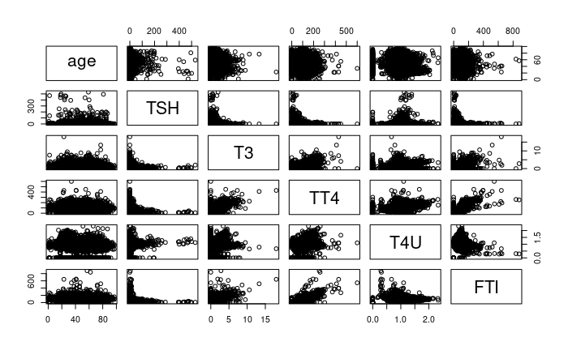

```r
numeric.attrs <- thyroid.df[,c("age", "TSH", "T3", "TT4", "T4U", "FTI")]
pairs(numeric.attrs)
```

En base a lo observado en los distintos diagramas de dispersión nos concentraremos en los diagramas cuya relación sea entre los niveles de hormona TSH en la sangre y los niveles de hormona en la sangre para T3 y TT4. Esto ya que son los principales agentes detectores de la enfermedad de la tiroides.

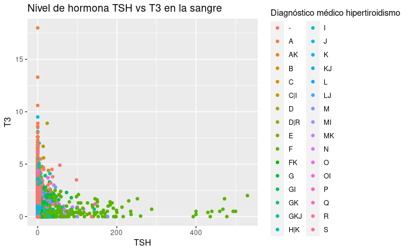

```r
ggplot(thyroid.df) +
  geom_point(aes(x=TSH, y=T3, color=target)) +
  ggtitle("Nivel de hormona TSH vs T3 en la sangre") + xlab("TSH") + ylab("T3") + labs(color="Diagnóstico médico hipertiroidismo")
```

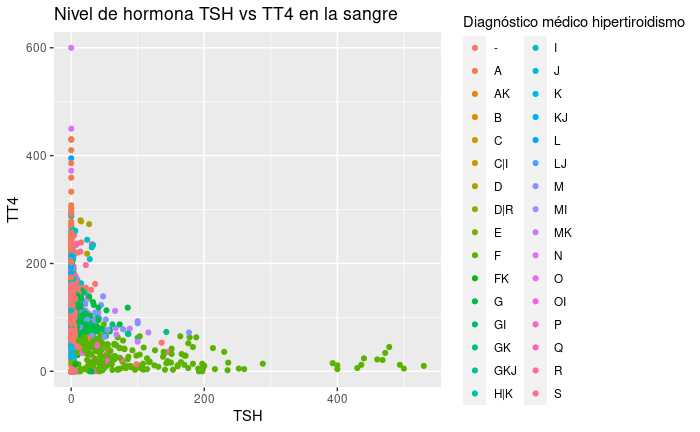

```r
ggplot(thyroid.df) +
  geom_point(aes(x=TSH, y=TT4, color=target)) +
  ggtitle("Nivel de hormona TSH vs TT4 en la sangre") + xlab("TSH")  + ylab("TT4") + labs(color="Diagnóstico médico hipertiroidismo")
```

### Histogramas

Se realizan los histogramas basados en edad y género, además se incluye un histograma que considera los diagnósticos previamente descritos. En la primera parte, se decide crear una nueva columna que tenga consigo las edades pero distribuidas en rangos, todo esto con el fin de poder encontrar mejores resultados posteriormente.

```r
# Primero se crea una columna donde se tengan los años por rangos
rangos <- c(0, 18, 30, 40, 50, 60,70,80,90, Inf)
etiquetas <- c("0-18", "19-30", "31-40", "41-50", "51-60","61-70","71-80","81-90" ,"91+")
# Agrupa las edades por rangos
thyroid.df$grupo_edad <- cut(thyroid.df$age, breaks = rangos, labels = etiquetas, right = FALSE)
```

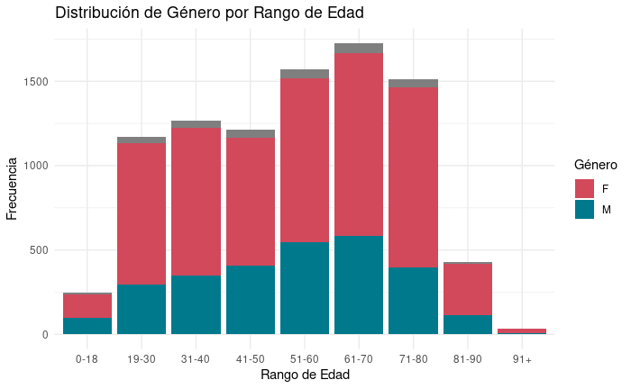

```r
# Histograma de género por rango de edades
ggplot(thyroid.df, aes(x = grupo_edad, fill = sex)) +
  geom_bar(position = "stack") +
  labs(title = "Distribución de Género por Rango de Edad",x = "Rango de Edad",y = "Frecuencia", fill= "Género") +
  theme_minimal() +
  scale_fill_manual(values = c("M" = "#00798c", "F" = "#d1495b"))
```

A partir del histograma, se observa que gran parte de los pacientes son del sexo femenino, además, se tiene que la población con mayor frecuencia dentro de los datos es la de entre 61-70 años, es decir, este estudio se concentra en adultos mayores, y la mayoría de ellos son del sexo femenino. Por otra parte, se tiene algunas barras de color gris, los cuales presentan información desconocida o no entregada por parte de los pacientes.

A continuación, se presenta un histograma que muestra la frecuencia de los diagnósticos, cabe destacar que en un principio se decide alterar la base de datos, de manera que los datos que aparecen “-” se eliminan para así poder visualizar de mejor manera los datos.

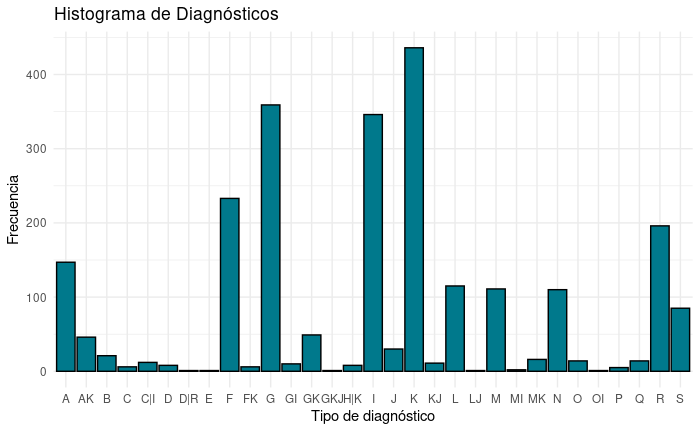

```r
#Se deja una nueva data eliminando los datos sin responder
datos_limpios <- thyroid.df %>%
  filter(!grepl("-", target))

# se crea el histograma con los datos limpios
ggplot(datos_limpios, aes(x = target)) +
  geom_bar(binwidth = 5, fill = "#00798c", color = "black") +
  labs(title = "Histograma de Diagnósticos",
       x = "Tipo de diagnóstico",
       y = "Frecuencia") +
  theme_minimal()
```

A partir del histograma, se observa que la mayoría de los pacientes están diagnósticados con “K - enfermedad no tiroidea concurrente” y luego le sigue “G - Hipotiroidismo compensado”.

### Relación entre variables: Cramer’s V, ANOVA Test y Correlación Lineal

Dado que muchas de nuestras variables son categóricas, no podemos calcular la correlación entre variables como lo hacemos con las variables numéricas. Es por ello, que utilizamos Cramer’s V. Cramer’s V mide la fuerza de asociación entre dos variables categóricas. Va entre 0 y 1, donde 0 representa una asociación débil, y 1 una fuerte.

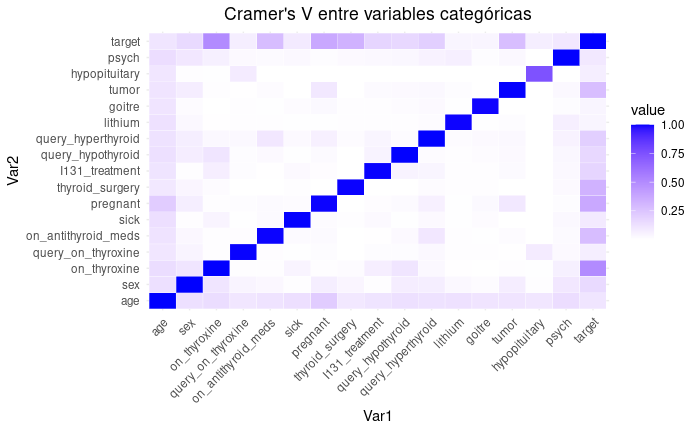

```r
cramersV <- function(chi2, n, phi = NULL) {
  k <- min(dim(phi)[1] - 1, dim(phi)[2] - 1)
  V <- sqrt(chi2 / (n * k))
  return(V)
}

data <- select(thyroid.df, -c("TSH","T3","TT4", "T4U", "FTI", "grupo_edad"))

correlation_matrix <- matrix(0, ncol(data), ncol(data))
colnames(correlation_matrix) <- names(data)
rownames(correlation_matrix) <- names(data)

for(i in 1:ncol(data)) {
  for(j in 1:ncol(data)) {
    contingency_table <- table(data[,i], data[,j])
    chi2 <- chisq.test(contingency_table)$statistic
    correlation_matrix[i, j] <- cramersV(chi2, nrow(data), contingency_table)
  }
}

melted_correlation <- melt(correlation_matrix)

ggplot(data = melted_correlation, aes(x=Var1, y=Var2)) +
  geom_tile(aes(fill=value), color='white') +
  scale_fill_gradient(low="white", high="blue") +
  theme_minimal() +
  ggtitle("Cramer's V entre variables categóricas") +
  theme(axis.text.x = element_text(angle = 45, hjust=1), plot.title = element_text(hjust = 0.5))
```

Como se puede observar, las variables que tienen una fuerza de asociación mayor son las que tienen un color más azul/morado oscuro. Un ejemplo es target con on_thyroxine, o target con thyroid_surgery.

Para poder obtener una relación entre variables numéricas y categóricas, utillizamos el test ANOVA, el cual analiza la relación una variable numérica y otra categórica. En este, se testea la hipótesis nula, que corresponde a que la media de la variable numérica es la misma para todas las categorías de la variable categórica. Luego, si el p-value es cercano a 0, menor a un nivel de significancia, se rechaza la hipótesis nula. Esto sugerería que hay una diferencia significativa en las medias de la variable numérica para cada categoría de la variable categórica. Además, se obtiene el effect size, que nos entrega información sobre la fuerza o magnitud de esta diferencia.

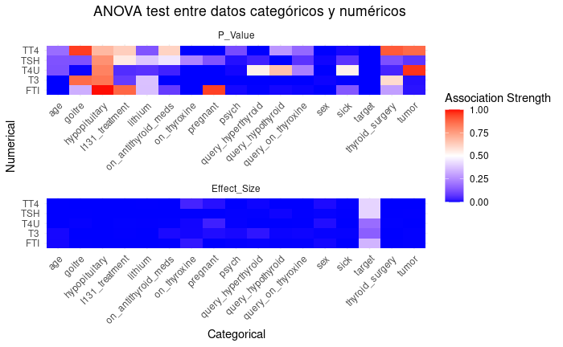

```r
df<- select(thyroid.df,-c("grupo_edad"))

#Especificar variables numéricas
numerical_vars <- c("TSH", "T3", "TT4","T4U", "FTI")


#Variables categóricas
categorical_vars <- setdiff(names(df), numerical_vars)

results <- data.frame()

#Para cada combinación de var categórica y numérica
for(num_var in numerical_vars) {
    p_values <- numeric()
    effect_sizes <- numeric()

    for(cat_var in categorical_vars) {
        formula_str <- paste(num_var, "~", cat_var)
        anova_result <- aov(as.formula(formula_str), data=df)

        #p-value
        p_values <- c(p_values, summary(anova_result)[[1]][["Pr(>F)"]][1])

        #effect size (eta squared)
        ss_total <- sum((df[[num_var]] - mean(df[[num_var]]))^2)
        eta_squared <- summary(anova_result)[[1]]["Sum Sq"][1,] / ss_total
        effect_sizes <- c(effect_sizes, eta_squared)
    }

    temp_results <- data.frame(Numerical=num_var, Categorical=categorical_vars, P_Value=p_values, Effect_Size=effect_sizes)
    results <- rbind(results, temp_results)
}


melted_results <- melt(results, id.vars=c("Numerical", "Categorical"))

# Plot
ggplot(melted_results, aes(x=Categorical, y=Numerical, fill=value)) +
    geom_tile() +
    facet_wrap(~ variable, scales="free", ncol=1) +
    scale_fill_gradient2(low="blue", mid="white", high="red", midpoint=0.5, limit=c(0,1)) +
    theme_minimal() +
    theme(axis.text.x = element_text(angle = 45, hjust=1)) +
    labs(title="ANOVA test entre datos categóricos y numéricos",fill="Association Strength")+
    theme(plot.title = element_text(hjust = 0.7))
```

Luego, se observa que para la variable categórica target, que contiene los diferentes diagnósticos médicos dados al paciente, se obtuvo un bajo p-value para las variables numéricas FTI, TT4, TSH, T4U, T3, los que fueron medidos en la sangre de los pacientes. Pero además, fueron donde se obtuvo un mayor effect size.

También, para obtener qué tan relacionados linealmente enter sí están las variables numéricas, podemos calcular la tabla de correlación entre ellas. Mientras más cercanos a 1, están más relacionadas entre sí, y cuando se acercan a 0, están menos relacionadas. Cuando son negativas, representa que por ejemplo, cuando una variable aumenta, la otra disminuye.

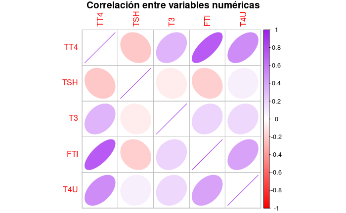

```r
data<-thyroid.df[c("TT4","TSH","T3","FTI","T4U")]
M <- cor(data)
title <- "Correlación entre variables numéricas"
corrplot(M, method = "ellipse",col=colorRampPalette(c("red","white","purple"))(100),title=title,mar=c(0,0,1,0))
```

```r
theme(plot.title = element_text(hjust = 0.7))
```

[output not shown]

### Boxplot: Variables numéricas v/s Target

Podemos utilizar boxplots, para visualizar de mejor manera la distribución de los datos numéricos entre los distintos tipos de diagnóstico médico (atributo “target”).

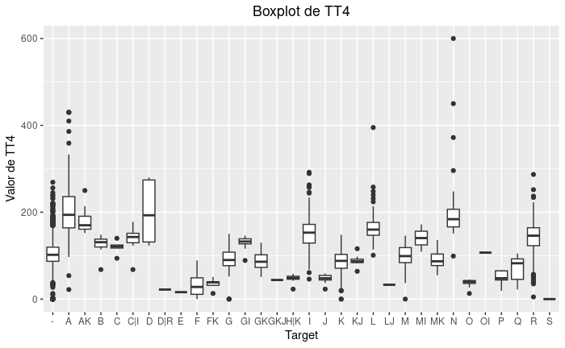

```r
ggplot(thyroid.df, aes(x=target, y=TT4)) +
  geom_boxplot() +
  labs(title="Boxplot de TT4", x="Target", y="Valor de TT4")+
  theme(plot.title = element_text(hjust = 0.5))
```

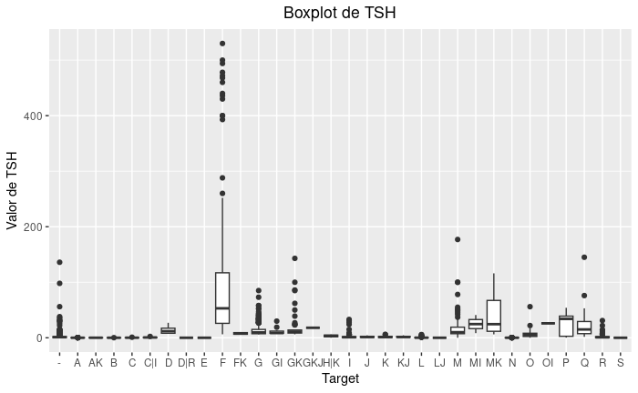

```r
ggplot(thyroid.df, aes(x=target, y=TSH)) +
  geom_boxplot() +
  labs(title="Boxplot de TSH", x="Target", y="Valor de TSH")+
  theme(plot.title = element_text(hjust = 0.5))
```

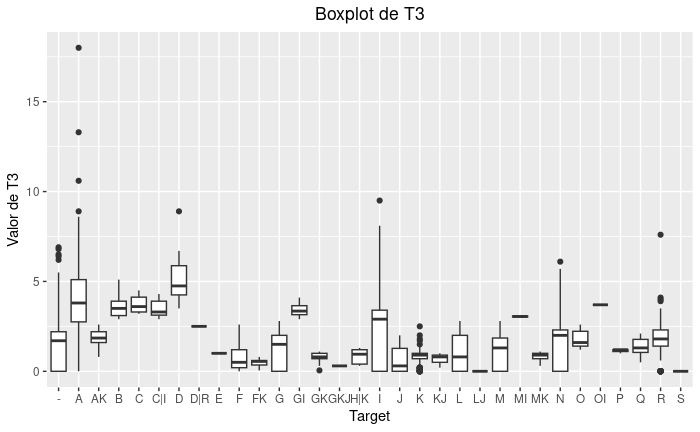

```r
ggplot(thyroid.df, aes(x=target, y=T3)) +
  geom_boxplot() +
  labs(title="Boxplot de T3", x="Target", y="Valor de T3")+
  theme(plot.title = element_text(hjust = 0.5))
```

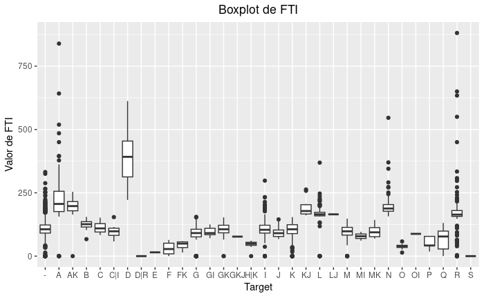

```r
ggplot(thyroid.df, aes(x=target, y=FTI)) +
  geom_boxplot() +
  labs(title="Boxplot de FTI", x="Target", y="Valor de FTI")+
  theme(plot.title = element_text(hjust = 0.5))
```

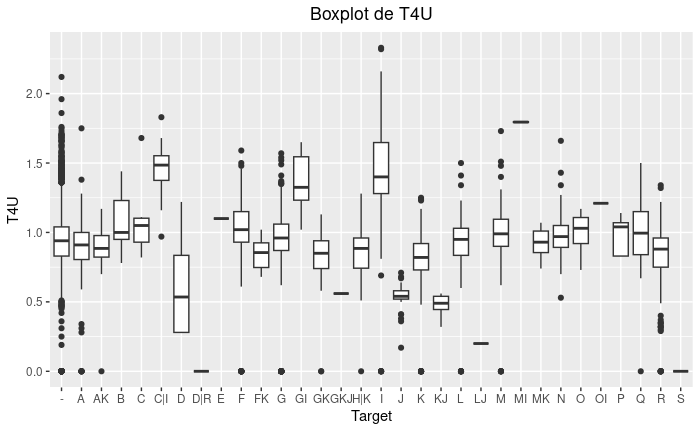

```r
ggplot(thyroid.df, aes(x=target, y=T4U)) +
  geom_boxplot() +
  labs(title="Boxplot de T4U", x="Target", y="T4U")+
  theme(plot.title = element_text(hjust = 0.5))
```

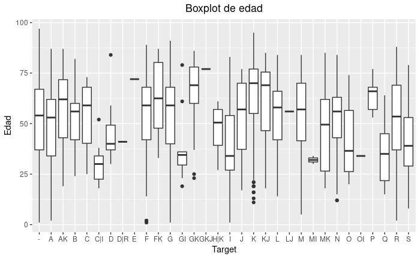

```r
ggplot(thyroid.df, aes(x=target, y=age)) +
  geom_boxplot() +
  labs(title="Boxplot de edad", x="Target", y="Edad")+
  theme(plot.title = element_text(hjust = 0.5))
```

## Preguntas y Problemas

- ¿Será posible predecir un resultado positivo en la hormona TT4 en función de pares de síntomas?
- ¿Se puede identificar un patrón de síntomas clínicos comunes en pacientes con niveles de TSH anormales?
- ¿Existen pacientes con características similares en función de algún criterio? ¿Será posible agruparlos?

Cada una de estas preguntas se responderán posteriormente, a partir de distintos métodos de clasificación, clustering, etc.

## Bibliografía

[1]https://www.comunicaciontucuman.gob.ar/noticia/salud/219811/dia-internacional-tiroides-buscan-concientizar-acerca-importancia [2]https://salud.nih.gov/recursos-de-salud/nih-noticias-de-salud/problemas-en-la-tiroides [3]https://www.cancer.net/es/tipos-de-cancer/c%C3%A1ncer-de-tiroides